# Q1: Train model with imbalance data

2, 3, 6 remains only 1% data

```python
import numpy as np
import pandas as pd
import pickle as pkl
import matplotlib.pyplot as plt

import PIL as pil

np.random.seed(0) # not sure why this random seed is not working
```

```python
from keras.datasets import mnist
(X_train_origin, y_train_origin), (X_test, y_test) = mnist.load_data()
```

```python
'''
Visualization helpers
'''

def visualize_y_distribution(y, save_name=None):

    '''
    Plot distribution of y label in a given list of data
    '''

    x_ticks, counts = np.unique(y, return_counts=True)

    plt.title('Data distribution over y labels')
    plt.plot(counts)
    plt.xticks(x_ticks)
    plt.ylim(ymin=0)
    plt.show()

    if save_name:
        plt.savefig(save_name)

def visualize_prediction(predict, save_name=None):

    '''
    Plot the distribution of predition classes
    '''

    # visualize prediction in each classes
    x_ticks, counts = np.unique(predict, return_counts=True)

    counts = [counts[np.where(x_ticks==i)[0]] if i in x_ticks else 0 for i in range(10)]
    x_ticks = np.arange(10)

    plt.title('Prediction in each classes')
    plt.plot(counts)
    plt.xticks(x_ticks)
    plt.ylim(ymin=0)
    plt.show()

    if save_name:
        plt.savefig(save_name)

    return counts


def plot_sample(sample, show=True):

    '''
    Plot a sample
    '''

    plt.imshow(sample, cmap='gray')
    if show:
        plt.show()


def plot_samples_overlay(dataset, show=True):

    '''
    Plot a set of samples' overlay
    '''

    dataset = dataset.astype('int')
    avg = np.round(sum(dataset) / dataset.shape[0])
    plot_sample(avg, show=show)


def plot_overlay_compare(origin, treatment):

    '''
    Plot two overrlay side-by-side for comparison
    '''

    fig = plt.figure()

    fig1 = fig.add_subplot(1,2,1)
    fig1.set_title('origin')
    plot_samples_overlay(origin, show=False)

    fig2 = fig.add_subplot(1,2,2)
    plot_samples_overlay(treatment, show=False)
    fig2.set_title('treatment')

    plt.show()


def plot_overlay_of_classes(X, y, classes=None, name=None):

    '''
    Designate classes in list to visualize at once
    '''

    fig = plt.figure()

    if type(classes)==list:
        iterate = classes
    else:
        iterate = range(10)

    for i,v in enumerate(iterate):
        sub = fig.add_subplot(1,len(iterate),i+1)
        sub.axis('off')
        sub.set_title(str(v))
        plot_samples_overlay(X[y==v], show=False)

    fig.suptitle(name if name else 'No_title')
    plt.show()
```

```python
'''
Remove 99% data in classes [2,3,6]
'''

retain_ratio = 0.01
victims = [2,3,6]

def rm_99_percent_data_of(X, y, victims):

    retain_idxes = []
    victim_idxes = [[] for i in range(len(victims))] # note: [[]]*len(victims) will copy reference instead of deep copy
    for i,yy in enumerate(y):
        is_victim = False
        for j,vic in enumerate(victims):
            if yy==vic:
                victim_idxes[j].append(i)
                is_victim = True
                break
        if not is_victim:
            retain_idxes.append(i)

    # random retain 1% data
    removed_idxes = []
    for i in range(len(victim_idxes)):
        retain_size = round(len(victim_idxes[i])*retain_ratio)
        np.random.shuffle(victim_idxes[i])
        retain_idxes += victim_idxes[i][:retain_size]
        removed_idxes += victim_idxes[i][retain_size:]

    return X[retain_idxes], y[retain_idxes], removed_idxes

X_train_skew, y_train_skew, removed_idxes = rm_99_percent_data_of(X_train_origin, y_train_origin, victims)
```

```python
'''
Check removal result is valid
'''

print('Set of removed y:',set(y_train_origin[removed_idxes]))


'''
Check retained labels has approximately 1% data (about 60 in our case)
'''

counter = lambda y,label: sum(y==label)
print('Remaining counts:', {v:counter(y_train_skew, v) for v in victims})
```

```
Set of removed y: {2, 3, 6}
Remaining counts: {2: 60, 3: 61, 6: 59}
```

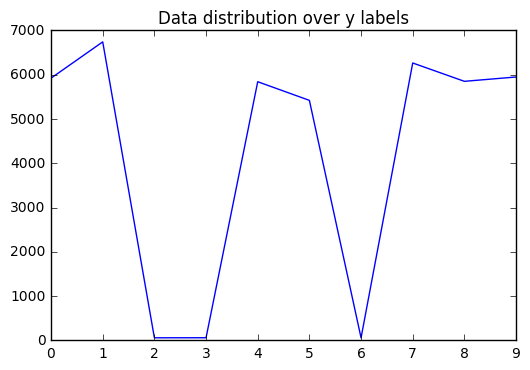

```python
'''
Visualize
'''

visualize_y_distribution(y_train_skew)
```

## Random split validation data

Note that this validation data is for model training.

Although theoretically we need to do N-fold validation, but we only care about performance difference.

So I'll do simple holdout validation, it should be fine here since we have high accuracy and simple data.

```python
train_ratio = 0.8 # 0.7 is also good, but I prefer 0.8

def expand_y(y):

    '''
    Reshape the y label for later training
    '''

    ret = np.zeros( (y.shape[0], 10) )
    for i,yy in enumerate(y):
        ret[i,yy] = 1
    return ret


def prepare_train_val(X, y):

    '''
    Prepare data.
    Include split train/val set, and reshape y to one-hot form.
    '''

    train_size = round(X.shape[0]*train_ratio)

    shuffle_idxes = np.arange(X.shape[0])
    np.random.shuffle(shuffle_idxes)

    train_idxes = shuffle_idxes[:train_size]
    val_idxes = shuffle_idxes[train_size:]

    X_val = X[val_idxes]
    X_train = X[train_idxes]
    y_val = expand_y(y[val_idxes])
    y_train = expand_y(y[train_idxes])

    return X_train, y_train, X_val, y_val

X_train, y_train, X_val, y_val = prepare_train_val(X_train_skew, y_train_skew)
```

```python
print('Train shape:', X_train.shape)
print('Validation shape:', X_val.shape)
print('Test shape:', X_test.shape)
```

```
Train shape: (33738, 28, 28)
Validation shape: (8435, 28, 28)
Test shape: (10000, 28, 28)
```

## Start build model

Note that I didn't spend too much time on model tuning since it's not the most important part of this exercise.

I use a VGG-like simple architecture.

```python
from keras.models import Model
from keras.layers import Dense, Input, Reshape, Activation, Flatten, Dropout, BatchNormalization
from keras.layers.convolutional import Conv2D, MaxPooling2D
from keras.optimizers import Nadam
from keras.callbacks import EarlyStopping, ModelCheckpoint

def build_model():
    input_shape = X_train.shape[1:]
    img_input = Input(shape=input_shape)
    data = Reshape(target_shape=(1,input_shape[0],input_shape[1]))(img_input)

    data = Conv2D(filters=32, kernel_size=2, padding='same')(data)
    data = MaxPooling2D(pool_size=(2,2), padding='same')(data)
    data = Conv2D(filters=32, kernel_size=2, padding='same')(data)
    data = MaxPooling2D(pool_size=(2,2), padding='same')(data)

    data = Activation('relu')(data)

    data = Conv2D(filters=64, kernel_size=2, padding='same')(data)
    data = MaxPooling2D(pool_size=(2,2), padding='same')(data)
    data = Conv2D(filters=64, kernel_size=2, padding='same')(data)
    data = MaxPooling2D(pool_size=(2,2), padding='same')(data)

    data = Activation('relu')(data)

    data = Conv2D(filters=128, kernel_size=2, padding='same')(data)
    data = MaxPooling2D(pool_size=(2,2), padding='same')(data)
    data = Conv2D(filters=128, kernel_size=2, padding='same')(data)
    data = MaxPooling2D(pool_size=(2,2), padding='same')(data)

    data = Flatten()(data) # shape here is (1,1,128)

    data = Dense(64)(data)
    data = Dense(64)(data)
    data = Dense(32)(data)
    data = Dense(32)(data)

    out = Dense(10, activation='softmax')(data)

    model = Model(inputs=img_input, outputs=out)

    model.compile(loss='categorical_crossentropy',
            optimizer=Nadam(lr=0.002, clipnorm=0.5),
            metrics=['acc'])

    return model
```

```python
def train(model, train, validation, save_path=None, patience=3, batch_size=512,monitor_policy = 'val_acc'):

    save_path = save_path if save_path else './tmp.model'

    X_train, y_train = train
    X_val, y_val = validation

    early_stopping =EarlyStopping(monitor=monitor_policy, patience=patience)
    model_checkpoint = ModelCheckpoint(save_path, save_best_only=True, save_weights_only=True)

    try:
        # model.summary()
        hist = model.fit(X_train,
                         y_train,
                         validation_data=(X_val, y_val),
                         epochs=200,
                         batch_size=batch_size,
                         shuffle=True,
                         callbacks=[early_stopping, model_checkpoint],
                         verbose=1
                        )
    except Exception as e:
        if type(e)==KeyboardInterrupt:
            print('Interrupt by user')
        else:
            raise(e)

    model.load_weights(save_path)
    bst_val_score = max(hist.history['val_acc'])
    return bst_val_score
```

```python
model = build_model()
val_acc_skew = train(model, (X_train, y_train), (X_val, y_val), save_path='./mnist_model.h5')
```

```
Train on 33738 samples, validate on 8435 samples
```

```python
def transform_prediction(predict):

    '''
    Transform prediction from one-hot to numeric
    '''

    return np.array([np.argmax(pp) for pp in predict])


def calc_acc(predict, truth):

    '''
    Compute accuracy
    '''

    predict_trans = transform_prediction(predict)
    return sum(predict_trans==truth)/predict.shape[0], predict_trans
```

#### Prediction

```
Best validation accuracy: 0.985180794663
Test set accuracy: 0.8596
```

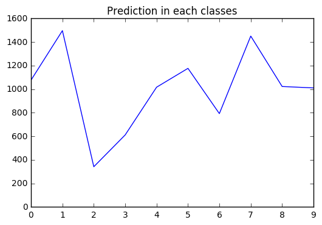

```
Prediction count of 2 : [342]
Prediction count of 3 : [612]
Prediction count of 6 : [793]
```

```python
print('Best validation accuracy:', val_acc_skew)

prediction = model.predict(X_test)
test_acc_skew, predict = calc_acc(prediction, y_test)
print('Test set accuracy:', test_acc_skew)

counts = visualize_prediction(predict)

for v in victims:
    print('Prediction count of',v,':',counts[v])
```

## Fast conclusion

1. Test set has -0.12 (0.985->0.86) performance difference in terms of accuracy, comparing to validation accuracy.

   ```
    Accuracy drop is totally as expected.
    This is totally data problem.
    Can either be explained by:

        A. The distribution of training data is different to real world data causes regression.
           The samples in classes [2,3,6] are all too few. Making our model prefers to give other classes higher probability.

        B. Or sometimes even worse, model will totally give up to learn the classes whom rarely appears.
           Since those classes rarely update weights, the previous hidden layers are all fully controlled by other classes.
           Thus the model can't really learn any information to support the prediction on such rare classes.

    This issue shouldn't happen at all if we "carefully" obtain the training data from true user events.
    But engineers still need to clean up the mess if such tragedy happens :(
   ```

2. [2,3,6] classes has lower trigger rate compare to other classes is expected.

   ```
    But it surprised me that the model still outputs so many predictions in [2,3,6] classes.
    I thought it will totally ignore those 3 classes.
    Maybe my model is too complex such that it overfits to the samples in classes [2,3,6], so it can identify very similar samples in the testing set.
    It is an interesting result, but I got to be hurry ;(
   ```

# Q2: How to solve it?

I came up with 3 solutions:

1. [Naive] Simply upsampling or tuning the class weights during training.

   ```
    Pros:
        1. Easy to do.
        2. Very possible to work.
    Cons:
        1. [2,3,6] classes are extremely imbalanced, we might overfit to the very small training data of classes [2,3,6].
        2. The improvement (accuracy classes [2,3,6] or overall accuracy) is not gauranteed, although this often works.

    So I won't do this.
    Although it can be used as a baseline, but I will use data augmentation later, making this baseline meaningless.
   ```

2. [Acceptable] Combine data augmentation and up/down sampling.

   ```
    Basically, the only difference comparing to previous solution is adding data augmentation.
    Since the key problem of identifying classes [2,3,6] is they are lack of data. So data augmentation should help them a lot.
    And we can tune the appearance probability of each class, since we already "somehow" knows that number 0~9 appears almost equally in real world data.
   ```

3. [Ultimate weapon] GAN (will not and no need do it here)

   ```
    Although data augmentation should work, but we still aren't very sure if the data of classes [2,3,6] is enough or not.
    If the answer is no, we probably need to use GAN to generate new and high quality data.
    There are still plenty of problems if we adapt this approach:

    Q1: We already lack of data, can the GAN training success?

            I don't know, but worth a try if necessary.

    Q2: How to gaurantee "high-quality"?

            Yep, another challenge. Maybe use an autoencoder to do data selection is applicable? I'm not very sure about that.
            Apple just published a paper about how to generate high-quality image data in CVPR, maybe we can find some idea there.
            (I still don't have time to read it ;( )
   ```

4. What's next?

   ```
    I don't really know.
    But I'm very sure the golden key is generating more high quality data to solve the data problem.
    Maybe try some more traditional ways to generate more data.
    For example, find a way to interpolate a new "6" from two different "6".
   ```

## Solution 1 : [Baseline] direct up-sampling

```python
def duplicate_class_samples(class_label, X, y, target_size):
    class_position = y==class_label
    X_class = X[class_position]
    y_class = y[class_position]
    diff = target_size - X_class.shape[0]
    dup_index = np.random.randint(0,X_class.shape[0],size=diff)
    return X_class[dup_index], y_class[dup_index]
```

```python
non_victims = [i for i in range(10) if i not in victims]
sample_sizes = [np.sum(y_train_origin==v) for v in non_victims]
average_sample_size = int(np.mean(sample_sizes))

duplicate_samples = np.array([duplicate_class_samples(v, X_train_skew, y_train_skew, average_sample_size) for v in victims])

X_train_dup = np.vstack([X_train_skew] + duplicate_samples[:,0].tolist())
y_train_dup = np.hstack([y_train_skew] + duplicate_samples[:,1].tolist())
```

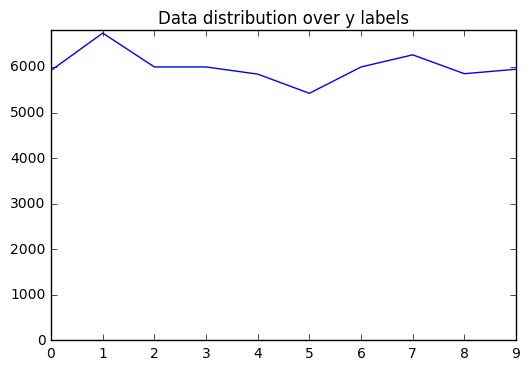

```python
visualize_y_distribution(y_train_dup)
```

#### Look pretty good, let's train model again

```python
X_train, y_train, X_val, y_val = prepare_train_val(X_train_dup, y_train_dup)

model = build_model()
val_acc_dup = train(model, (X_train, y_train), (X_val, y_val), save_path='./mnist_model_duplicate_samples.h5')
```

```
Train on 47992 samples, validate on 11998 samples
```

#### Prediction

```
Best validation accuracy: 0.986164360876
Test set accuracy: 0.9138
```

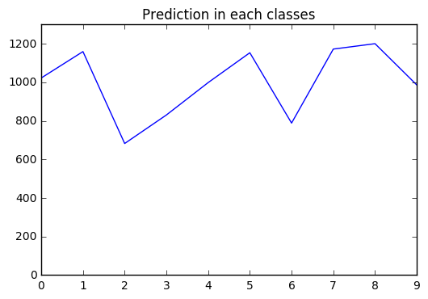

```
Prediction count of 2 : [683]
Prediction count of 3 : [831]
Prediction count of 6 : [789]
```

```python
print('Best validation accuracy:', val_acc_dup)

prediction = model.predict(X_test)
test_acc_dup, predict = calc_acc(prediction, y_test)
print('Test set accuracy:', test_acc_dup)

counts = visualize_prediction(predict)

for v in victims:
    print('Prediction count of',v,':',counts[v])
```

#### Fast conclusion

1. Looks good. Test accuracy boost from 0.86 to 0.914.

   ```
    Yes, we fixed the problem of data distribution over classes. So the accuracy gain is expected.
   ```

2. However, we can still observe notable regression in classes [2,3,6].

   ```
    Expected, the real training samples in classes [2,3,6] is still too few.
    The model can extremely overfit to those small sample set, since we have dense (fully-connected) layers.
    So if a new sample of class [2,3,6] appears with a little displacement or rotation, the model can't identify them.
   ```

## Solution 2 : [Better] use augmented data while upsampling

Note:

I only augment classes [2,3,6].

Since data augmentation itself can provide unpredictable benefit to any data. The comparison of validation/testing score will become meaningless if we apply it to all classes because we don't know how much improvement do augmentation technique provide to other classes.

### Simple visualize

A simple visualization by overlaying all images in same class together (pixel-wise summation then average it).

Let's see how data difference between testing data and our training data after duplication.  
It can be a good clue for us to properly generate good augmented data.

#### Note:

Theoretically, we don't have access to testing data.  
But it becomes a paradox when it comes to how we found the testing data's distribution is different to training data (LOL)

So anyway, I'll use testing data for augmentation pipeline hyperparameter choosing.  
I think this operation won't leak too much information from testing set to our model.

In real life, we need to collect new data after this operation. (for safety)

#### direct_duplicate v.s. testing data

We can see that there's no much difference between training data and testing data in classes [4,8,9], which we didn't touch.

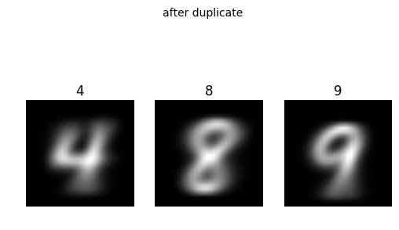

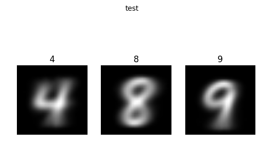

```python
plot_overlay_of_classes(X_train_dup, y_train_dup, classes=[4,8,9], name='after duplicate')
plot_overlay_of_classes(X_test, y_test, classes=[4,8,9], name='test')
```

#### But in classes [2,3,6], the difference is notable.

It is very clear that the overlay image of our training samples (which scaled down 99%) looks like have lots of edges and corners on it.

The difference is caused by non-uniformity of our training samples, since the sample is sparsely located in the overlay image.

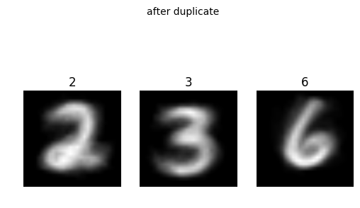

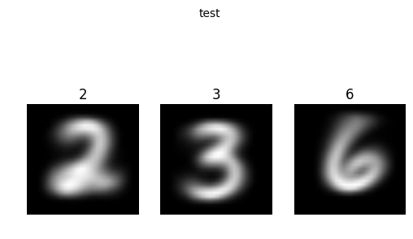

```python
# plot_overlay_of_classes(X_train_origin, y_train_origin, classes=[2,3,6], name='original') # we don't have access to it in real life ;(
plot_overlay_of_classes(X_train_dup, y_train_dup, classes=[2,3,6], name='after duplicate')
plot_overlay_of_classes(X_test, y_test, classes=[2,3,6], name='test')
```

#### Start augmentation

I choose translate (1 px since our image is too small) / rotate (3 degree) / shear (3 degree).

Which are very elemetary choices.

```python
# Augmentation tool:   imgaug
# Github :             https://github.com/aleju/imgaug
# Install :            pip install git+https://github.com/aleju/imgaug

import imgaug as ia
from imgaug import augmenters as iaa

ia.seed(1)
'''
Input:
    src: augmentation source images
    label: class label
    size: augment output size

Output:
    X,y augmentated new samples (not including input)
'''
def augmentation(src, label, size):

    seq = iaa.Sequential([
#         iaa.PerspectiveTransform(scale=0.05), # can't use it in greyscale QQ
        iaa.Affine(
            translate_percent={"x": (-0.04, 0.04), "y": (-0.04, 0.04)}, # 0.04 * 28 (px) = 1.12px ~= 1px
            rotate=(-3, 3),
            shear=(-3, 3)

        )
    ], random_order=True) # apply augmenters in random order

    augmented = np.array([seq.augment_image(src[np.random.randint(0,src.shape[0])]) for i in range(size)])
    return augmented, np.repeat(label, size)
```

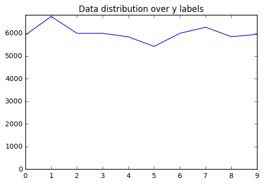

```python
augment_output = np.array([augmentation(X_train_skew[y_train_skew==v], v, average_sample_size-counter(y_train_skew,v)) for v in victims])
augment_X = augment_output[:,0]
augment_y = augment_output[:,1]

X_train_augment = np.vstack([X_train_skew] + augment_X.tolist())
y_train_augment = np.hstack([y_train_skew] + augment_y.tolist())

visualize_y_distribution(y_train_augment)
```

#### Augmetation result

Looks pretty nice except our samples looks a little blur (i.e. the augmented samples' distribution is too uniform).

But it should already have notable improvement at this stage.

**Note:**

A better solution is to generate augmented data with normal distribution, i.e. generate more data which closer to real data.

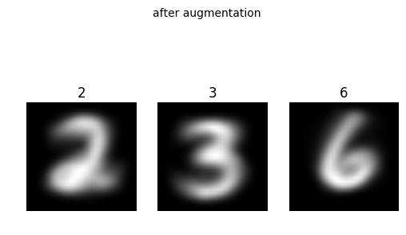

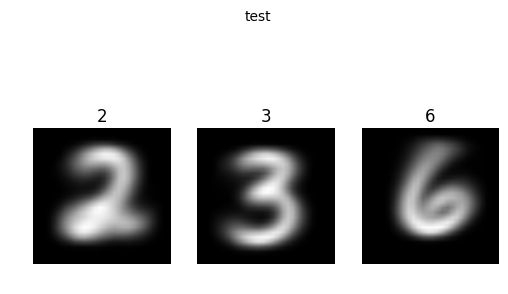

```python
plot_overlay_of_classes(X_train_augment, y_train_augment, classes=[2,3,6], name='after augmentation')
plot_overlay_of_classes(X_test, y_test, classes=[2,3,6], name='test')
```

```python
X_train, y_train, X_val, y_val = prepare_train_val(X_train_augment, y_train_augment)

model = build_model()
val_acc_aug = train(model, (X_train, y_train), (X_val, y_val), save_path='./mnist_model_augmentation.h5')
```

```
Train on 47992 samples, validate on 11998 samples
```

#### Prediction

```
Best validation accuracy: 0.989581597082
Test set accuracy: 0.9629
```

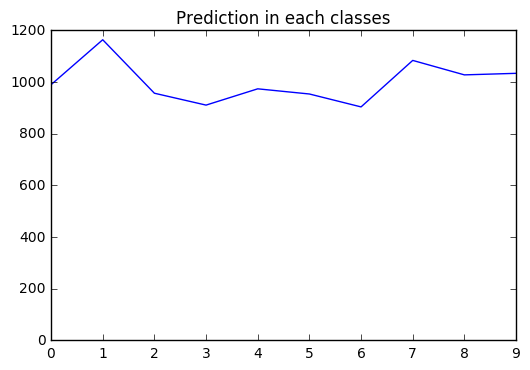

```
Prediction count of 2 : [957]
Prediction count of 3 : [911]
Prediction count of 6 : [904]
```

```python
print('Best validation accuracy:', val_acc_aug)

prediction = model.predict(X_test)
test_acc_aug, predict = calc_acc(prediction, y_test)
print('Test set accuracy:', test_acc_aug)

counts = visualize_prediction(predict)

for v in victims:
    print('Prediction count of',v,':',counts[v])
```

#### Summary

```python
from prettytable import PrettyTable

val_acc_without_rm_236 = 0.9896
test_acc_without_rm_236 = 0.9781

t = PrettyTable(['Run name','Validation accuracy', 'Testing accuracy', 'Diff'])
t.add_row(['Without removing 99% data from classes [2,3,6]', val_acc_without_rm_236, test_acc_without_rm_236, round(test_acc_without_rm_236-val_acc_without_rm_236,6)])
t.add_row(['Skew (raw)', val_acc_skew, test_acc_skew, round(test_acc_skew-val_acc_skew,6)])
t.add_row(['Upsample by duplicate', val_acc_dup, test_acc_dup, round(test_acc_dup-val_acc_dup,6)])
t.add_row(['Upsample by augmentation', val_acc_aug, test_acc_aug, round(test_acc_aug-val_acc_aug,6)])
print(t)
```

```
+------------------------------------------------+---------------------+------------------+-----------+
|                    Run name                    | Validation accuracy | Testing accuracy |    Diff   |
+------------------------------------------------+---------------------+------------------+-----------+
| Without removing 99% data from classes [2,3,6] |        0.9896       |      0.9781      |  -0.0115  |
|                   Skew (raw)                   |    0.985180794663   |      0.8596      | -0.125581 |
|             Upsample by duplicate              |    0.986164360876   |      0.9138      | -0.072364 |
|            Upsample by augmentation            |    0.989581597082   |      0.9629      | -0.026682 |
+------------------------------------------------+---------------------+------------------+-----------+
```

## Conclution

1. The result already looks pretty good in terms of both accuracy prediction distribution.

   ```
    Accuracy difference between validation set and testing set is only 0.027 ( 0.99 -> 0.963 ).
    Seems like there's no need to use GAN or other fancy technologies.

    By fine-tuning the augmentatio hyper-parameters, I optimistically guess we can enclose the accuracy gap to 0.02.
   ```

2. Why data augmentation works so good?

   ```
    Since hand-writing digits data is very simple and easy to distinguish.
    I think the key problems are:

        A. Label distribution different (solve by up-sampling)

        B. Classes [2,3,6] appears too rarely. (solve by up-sampling)
           Model can't properly store information into hidden nodes since other classes update too frequetly.

        C. Sample size of classes [2,3,6] is too small, model overfits to it. (solve by data augmentation)
           The overfitting is happened in the dense layers (or fully-connected layers) since dense layer is positional sensitive.

    Since the key problems are all solved, so good performance is expected.
    But since we still lack of data diversity in classes [2,3,6].
    I wouldn't be surprised if there's remaining regression in those classes.
   ```

3. There are some things I didn't do since the key problem of this exercise is data distribution.

   ```
    A. K-fold validation.

        The accuracy varies for different random seed.
        (But I'm pretty sure that the result is consistently augmetation>duplication>skew).
        Also, the hyper-paramters / model structure should be tuned via validation.

    B. Other generalization components in model.

        Although we can solve overfitting problem by data augmentation,
        theoretically we can also solve it by adding dropout layer to our model's dense layer.
        But I found it doesn't work, maybe the sample size of classes [2,3,6] is really too small.
        Or, maybe we need more hyper-parameter tuning, not very sure about that.
   ```

## Appedix: what's model performance if we didn't remove 99% data from classes [2,3,6]

```python
X_train, y_train, X_val, y_val = prepare_train_val(X_train_origin, y_train_origin)

model = build_model()
val_acc_ori = train(model, (X_train, y_train), (X_val, y_val), save_path='./mnist_model_none_skew.h5')
```

```
Train on 48000 samples, validate on 12000 samples
```

```
Best validation accuracy: 0.989581597082
Test set accuracy: 0.9781
```

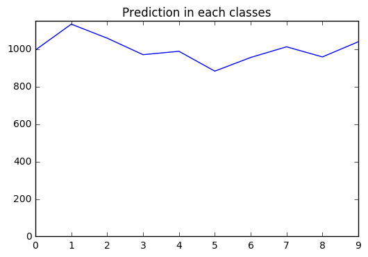

```
Prediction count of 2 : [1059]
Prediction count of 3 : [971]
Prediction count of 6 : [956]
```

```python
print('Best validation accuracy:', val_acc_aug)

prediction = model.predict(X_test)
test_acc_ori, predict = calc_acc(prediction, y_test)
print('Test set accuracy:', test_acc_ori)

counts = visualize_prediction(predict)

for v in victims:
    print('Prediction count of',v,':',counts[v])
```